# Explainer Notebook for the Project 'Analysis of Temporal and Geographical Changes in Bird Migration Patterns in North America' Part 1

By Group 9 (Agathe (s243230), Shireesha (s190030), and Simone (s241647))

# History

The North American Bird Banding Program (NABBP), administered by the U.S. Geological Survey (USGS) Bird Banding Laboratory and the Canadian Wildlife Service's Bird Banding Office, uses standardized event types to categorize different bird banding activities.

For some context, bird banding in North America was first introduced in 1803 by John James Audubon, who tied silver wire around the legs of nestling eastern phoebes, two of which returned the following spring. Later on in 1882 Ernest Thompson Seton used printer's ink to mark snow buntings. In 1996, the North American Banding Council (NABC) was formed. Their mission was to train banders in safe, ethical practices of the capture and handling of wild birds (Wikipedia, 2021).

# Motivation

Experts say that recent data suggests bird populations in North America have seen a loss of more than 1 in 4 birds since 1970. That's approximatelt 2.9 billion birds, a finding from the first-ever comprehensible assessment of the net population changes of birds in the United States and Canada (Cornell Lab of Ornithology, 2019). Some of the major reasons for this include, but is not limited to, habitat loss caused by agricultural intensification, urbanization, and climate change. 1 billion birds are found to die each year just from collision with windows alone, a direct result of increased urbanization (Ashburn, 2024).

This trend is happening amongst birds in every biome. Forest birds have seen a decline of 1 billion birds. Grassland birds have collectively declined around 53% or 720 million birds. What's more, the greatest losses are seen amongst the most common birds, from popular sights in bird feeders such as white-throated sparrows, to common sightings in nature, such as the red-winged blackbird. More than 90% if the overall losses are from just 12 families of common species, including sparrows, blackbirds, warblers, and finches (Cornell Lab of Ornithology, 2019).

As such, this project aims to see if bird migration patterns in North America between the 1970s and the 2010s, using data collected from the U.S. Geological Survey ScienceBase Catalog will show us a similar story, determining if bird banding is a useful tool in the analysis of bird trends caused by external factors such as agriculture expansion, urbanization, and climate change.

We focus on seven bird species selected for their diversity, abundance of records, and their grouping within the dataset:

- Canada Goose
- Wood Duck
- Mourning Dove
- Tree Swallow
- Gray Catbird
- American Goldfinch
- White-throated Sparrow

To streamline the analysis, we retained only the data from 1970 and 2010, allowing for a clear comparison of migration patterns across these two decades. Each specie family in the dataset encompassed several species, so to main bias and to get a more streamlined overview, we chose to focus on one species from each family. Each of the chosen species furthermore has a good amount of data for analysis.

This website aim to understand the bird migration patterns changing in given time period and identify the number of banded birds are banded in banding events and their sub-divisons compare them with 1970s with 2010s.

Studies of bird migrations are important, banding in this century supports many other endeavors, including studies of avian behavior, ecology, and populations; preservation of endangered species; and regulating hunting of game species. In addition, banding activities provide information relevant to concerns for human health and safety—for example, West Nile disease and bird strikes near airports. Results from banding studies support international conservation programs like Partners in Flight and the North American Waterfowl Management Plan. ref: https://en.wikipedia.org/wiki/North_American_Bird_Banding_Program.

Our goal for the end user is to gain information and awareness regarding the decline of birds in North America and how this is not just an isolated issue but rather a sign of wider ecological problems. To further this point we have attempted to make as many of our graphs interactive as possible, to facilitate an interesting learning environment and give the user some freedom of choice rather than making our website one hundred percent strictly linear.

# Data Processing and Cleaning

To begin with data collection we used 7 csv files (groups 02, 04, 12, 28, 31, 39 and 44) from https://www.sciencebase.gov/catalog/item/653fa806d34ee4b6e05bc57d form 1960 to 2023. We started by merging the 7 files. To reduce the data size, we focused 1970s and 2010s decennies with focused 7 species by dropping the duplicates and keeping the less than 20% missing values features. We also removed the lines where the name of the specie was wrong.  
Now, the final data set does not contains any the duplicates. However, it have some null values in few features. The Event date, Band Type, latitude and longitude features are cleaned for analysis.

```python
import pandas as pd
import os
import sys
```

```python
def merge_data_files(list_files, output_file):

    df = pd.read_csv(list_files[0], on_bad_lines='skip')

    # Loop through the rest of the files and merge them into the DataFrame
    for file in list_files[1:]:
        new_df = pd.read_csv(file, on_bad_lines='skip')
        # Append the new DataFrame to the existing one
        df = pd.concat([df, new_df], ignore_index=True)

    # Save the merged DataFrame to a new CSV file
    df.to_csv(output_file, index=False)
```

```python
def process_data(input_file, output_file):
    # Read the input CSV file
    df = pd.read_csv(input_file)

    # Select years from 2010 to 2020 and from 1970 to 1980
    df = df[df['EVENT_YEAR'].between(
        2010, 2019) | df['EVENT_YEAR'].between(1970, 1979)]

    # Drop duplicates
    df = df.drop_duplicates()

    # Save the processed DataFrame to a new CSV file
    df.to_csv(output_file, index=False)
```

```python
def select_columns(input_file, threshold=20):
    # Read the input CSV file
    df = pd.read_csv(input_file)

    # Look at the percentage of missing values in each column
    missing_percentage = df.isnull().mean() * 100

    # Select columns with less than 20% missing values
    selected_columns = missing_percentage[missing_percentage < threshold].index.tolist(
    )

    print(
        f"Selected columns with less than {threshold}% missing values: {selected_columns}")

    return selected_columns
```

```python
def filter_columns(input_file, output_file, columns_to_keep):
    # Read the input CSV file
    df = pd.read_csv(input_file)

    # Filter the DataFrame to keep only the specified columns
    df = df[columns_to_keep]

    # Save the filtered DataFrame to a new CSV file
    df.to_csv(output_file, index=False)
```

```python
def filter_rows(input_file, output_file, column_name, value=None, nb_rows=100000):
    # Read the input CSV file
    df = pd.read_csv(input_file)

    # Filter the DataFrame to keep only rows where the specified column matches the value
    if value is not None:
        df = df[df[column_name] == value]
    else:
        # we keep only the value with more than nb_rows
        # Get the counts of each unique value in the specified column
        value_counts = df[column_name].value_counts()
        df = df[df[column_name].isin(
            value_counts[value_counts > nb_rows].index)]

    # Save the filtered DataFrame to a new CSV file
    df.to_csv(output_file, index=False)
```

```python
def main():
    list_files = []
    for file in os.listdir('./data'):
        if file.endswith('.csv'):
            list_files.append(os.path.join('./data', file))

    output_file = "merged_data.csv"
    merge_data_files(list_files, output_file)

    process_data("merged_data.csv", "processed_data.csv")

    selected_columns = select_columns(
        "processed_data.csv")

    filter_columns("processed_data.csv", "final_data.csv", selected_columns)

    filter_rows("data/final_data.csv", "data/final_data.csv",
                "SPECIES_NAME", value=None, nb_rows=100000)
    print("Data processing completed. Merged and filtered data saved to final_data.csv")
```

```python
#main()
```

```python
df= pd.read_csv("data/final_data.csv")
```

```python
# Define the mapping
band_type_map = {
    '4': '04', '4.0': '04',
    '1': '01','0': '00','11.0': '11',
    '2': '02'
}

# Apply the mapping
df['BAND_TYPE'] = df['BAND_TYPE'].replace(band_type_map)


# Convert BAND_TYPE to string to handle both string and int values
df['BAND_TYPE'] = df['BAND_TYPE'].astype(str)
```

```python
# Try converting to datetime, forcing errors to NaT (Not a Time)
df['Cl_EVENT_DATE'] = pd.to_datetime(df['EVENT_DATE'], errors='coerce')

# Filter rows with invalid dates
invalid_dates = df[df['Cl_EVENT_DATE'].isna()]

print("Invalid date entries:")
print(invalid_dates.count())

def fix_date(d):
    # Try swapping day and month
    try:
        return pd.to_datetime(d, format='%d/%m/%Y')
    except:
        return pd.NaT

# Try second attempt on invalid rows
df.loc[df['Cl_EVENT_DATE'].isna(), 'Cl_EVENT_DATE'] = df.loc[df['Cl_EVENT_DATE'].isna(), 'EVENT_DATE'].apply(fix_date)


df['Cl_EVENT_MONTH'] = df['Cl_EVENT_DATE'].dt.month.astype('Int64')

# 3) Extract the year as an integer
df['Cl_EVENT_YEAR'] = df['Cl_EVENT_DATE'].dt.year.astype('Int64')
df['Cl_EVENT_DAY'] = df['Cl_EVENT_DATE'].dt.day.astype('Int64')

# 4) Replace the original date column with the new one
df['EVENT_DATE'] = df['Cl_EVENT_DATE']
df['EVENT_MONTH'] = df['Cl_EVENT_MONTH']
df['EVENT_YEAR'] = df['Cl_EVENT_YEAR']
df['EVENT_DAY'] = df['Cl_EVENT_DAY']

# 5) Drop the temporary date columns
df.drop(columns=['Cl_EVENT_DATE', 'Cl_EVENT_MONTH',
                 'Cl_EVENT_YEAR', 'Cl_EVENT_DAY'], inplace=True)
```

```python
df['LON_DD']= df['LON_DD'].astype(float)
df['LAT_DD']= df['LAT_DD'].astype(float)
```

```python
df.to_csv("data/final_data.csv", index=False)
print("Data processing completed. Merged and filtered data saved to final_data.csv")
```

# Basic Statistics and general Data Analysis:

As for the data analysis, it was cruicial for us to refer to external sources to better understand our data and the implications of the real world on it. We learnt that bird banding is actually a pretty good indicator of the actual trends in bird population levels and migration patterns, which further underline the importance of such work. Furthermore, we also learnt how important birds are in understanding how nature in general is fairing.

```python
import pandas as pd
import matplotlib.pyplot as plt
import seaborn as sns
import calplot as cp
import plotly.express as px
from bokeh.plotting import figure, show
from bokeh.models import ColumnDataSource
from bokeh.io import output_notebook
import folium
import random
import geopandas as gpd
```

```python
#df = pd.read_csv('data\\final_data.csv')
df = pd.read_csv('data/final_data.csv')
print(" Size of the dataset is:",df.shape)
print("Number of duplicates:",df.duplicated().sum())
print(df.isnull().sum())
```

```
 Size of the dataset is: (4829164, 23)
Number of duplicates: 0
RECORD_ID               0
EVENT_TYPE              0
BAND                    0
ORIGINAL_BAND           0
EVENT_DATE           3648
EVENT_DAY            3648
EVENT_MONTH          3648
EVENT_YEAR           3648
SPECIES_ID              0
SPECIES_NAME            0
ISO_COUNTRY             0
ISO_SUBDIVISION      2879
LAT_DD                  0
LON_DD                  0
COORD_PREC            279
AGE_CODE           161677
SEX_CODE           161998
BIRD_STATUS        161348
EXTRA_INFO         161348
PERMIT             157586
BAND_STATUS        236264
BAND_TYPE               0
RECORD_SOURCE           0
dtype: int64
```

```
Total number of species in the dataset: 111070772

List of Focus species:
['Wood Duck' 'Mourning Dove' 'Tree Swallow' 'Gray Catbird'
 'American Goldfinch' 'White-throated Sparrow' 'Canada Goose']
There are 7 in total

Most common migrating specie: Canada Goose
Least frequently migrating specie: Tree Swallow
Number of species in each Category:
SPECIES_NAME
Canada Goose              1284279
Mourning Dove             1218423
Wood Duck                  626139
American Goldfinch         496279
White-throated Sparrow     469446
Gray Catbird               369533
Tree Swallow               365065
Name: count, dtype: int64
```

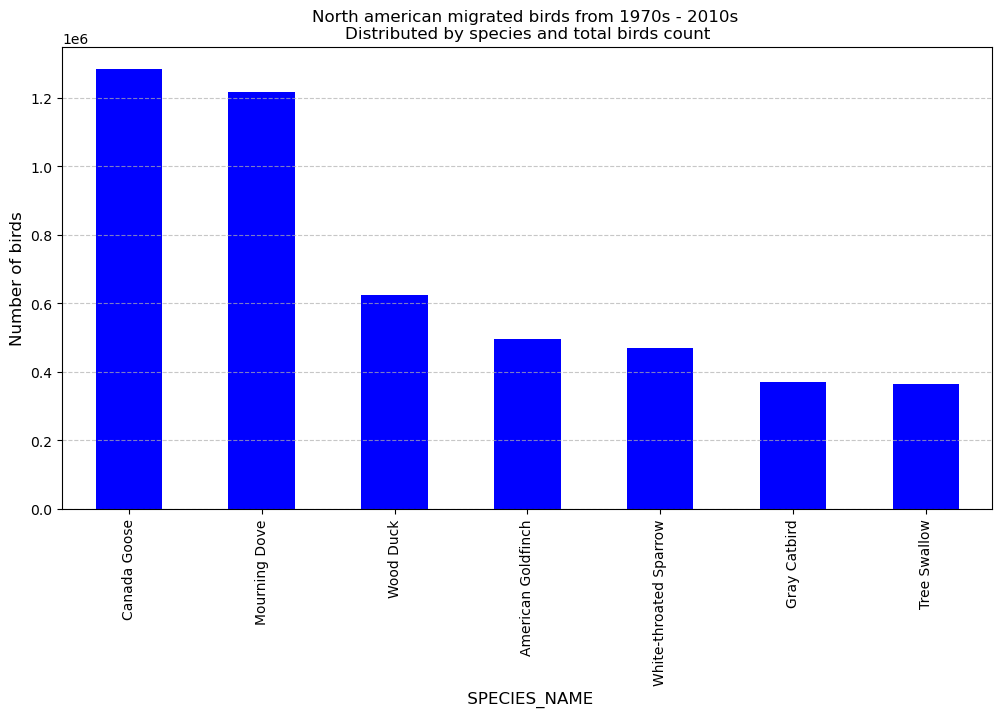

```python
#  General Statistics

# Report the total number of species in the dataset.
print(f"Total number of species in the dataset: {df.size}\n")
# List the focus categories of specie. How many are there?
print(f"List of Focus species: \n{df.SPECIES_NAME.unique()}")
print(f"There are {df.SPECIES_NAME.nunique()} in total\n")

print(f"Most common migrating specie: {df.SPECIES_NAME.value_counts().idxmax()}")
print(f"Least frequently migrating specie: {df.SPECIES_NAME.value_counts().idxmin()}")


specie_categories = df.SPECIES_NAME.value_counts()
# List the number of species in each SPECIES_NAME.
print(f"Number of species in each Category: \n{specie_categories}")

plt.figure(figsize=(12, 6))  # Set figure size
specie_categories.plot(kind="bar", color="blue")

plt.title("North american migrated birds from 1970s - 2010s \nDistributed by species and total birds count")
plt.xlabel(" SPECIES_NAME", fontsize=12)
plt.ylabel("Number of birds", fontsize=12)
plt.grid(axis="y", linestyle="--", alpha=0.7)
plt.show()
```

```
Year with most bird band events conducted: 1971.0. Count: 299230
Year with fewest bird band events: 1977.0. Count: 175587
```

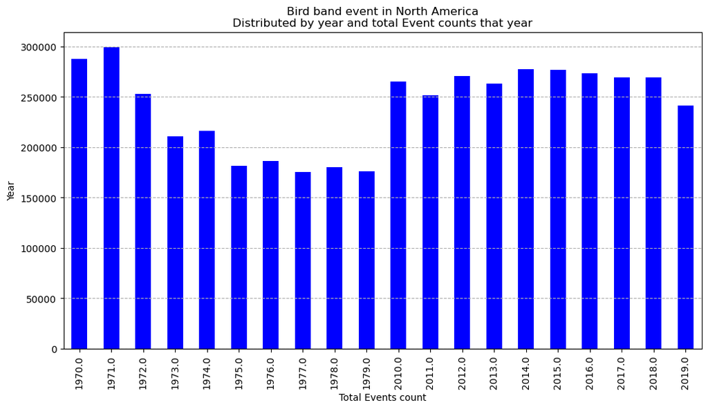

```python
# Bird band Events by species and event year

Birds_year = df['EVENT_YEAR'].value_counts().sort_index()

print(f"Year with most bird band events conducted: {(Birds_year.idxmax())}. Count: {Birds_year.max()}")
print(f"Year with fewest bird band events: {(Birds_year.idxmin())}. Count: {Birds_year.min()}")

plt.figure(figsize=(12, 6))
Birds_year.plot(kind="bar", color="blue")

plt.title("Bird band event in North America\nDistributed by year and total Event counts that year")
plt.xlabel("Total Events count")
plt.ylabel("Year")
plt.grid(axis="y", linestyle="--")
plt.show()
```

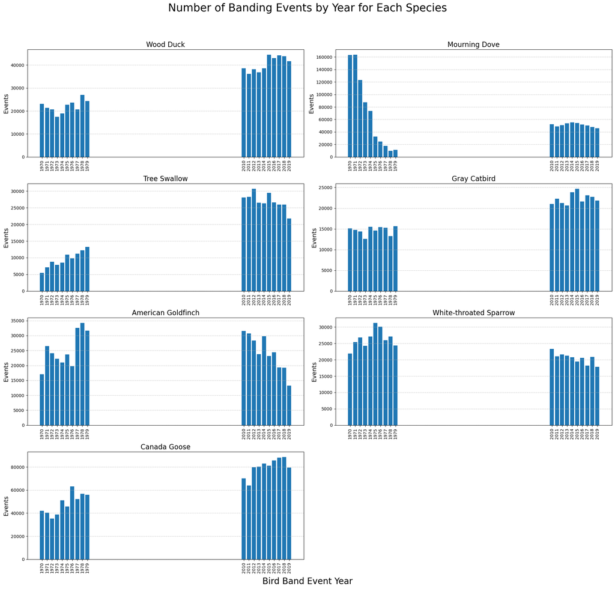

```python
# For each species, plot the number of banding events by year

focus_species = df.SPECIES_NAME.unique().tolist()

n = len(focus_species)
n_cols = 2
n_rows = (n + n_cols - 1) // n_cols

fig, axes = plt.subplots(n_rows, n_cols, figsize=(20, 5 * n_rows), sharex=False)
fig.suptitle('Number of Banding Events by Year for Each Species', fontsize=25)
axes = axes.flatten()

for idx, species in enumerate(focus_species):
    ax = axes[idx]

    # 1) Filter and count
    counts = (
        df.loc[df['SPECIES_NAME'] == species, 'EVENT_YEAR']
          .value_counts()
          .sort_index()
    )

    # 2) Plot
    if counts.empty:
        ax.text(0.5, 0.5, "No data", ha='center', va='center', fontsize=12, alpha=0.7)
    else:
        ax.bar(counts.index, counts.values)
        ax.set_xticks(counts.index)

    ax.set_title(species, fontsize=16)
    ax.tick_params(axis='x', rotation=90)
    ax.set_ylabel('Events', fontsize=14)
    ax.grid(axis='y', linestyle='--', alpha=0.7)

# remove any extra axes
for ax in axes[n:]:
    fig.delaxes(ax)

# common X-axis label
fig.text(0.5, 0.04, 'Bird Band Event Year', ha='center', fontsize=20)

plt.tight_layout(rect=[0, 0.05, 1, 0.95])
plt.show()
```

```
Wood Duck — monthly banding counts:
EVENT_MONTH
1.0      143160
2.0      143205
3.0      116426
4.0      172056
5.0      311410
6.0     1070330
7.0     1111446
8.0      790273
9.0      404162
10.0     363091
11.0     121385
12.0      78572
Name: count, dtype: int64

Wood Duck — seasonal banding counts:
SEASON
Winter     364937
Spring     599892
Summer    2972049
Fall       888638
Name: count, dtype: int64
```

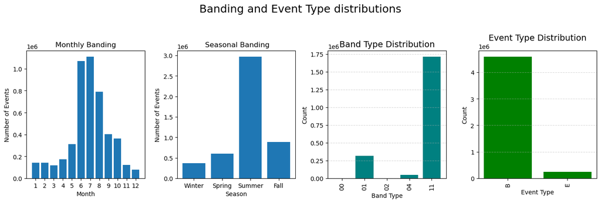

```python
# Banding and Event Type distributions

# 1) Map months to seasons
season_map = {
    12: 'Winter', 1: 'Winter', 2: 'Winter',
     3: 'Spring', 4: 'Spring', 5: 'Spring',
     6: 'Summer', 7: 'Summer', 8: 'Summer',
     9: 'Fall',  10: 'Fall',  11: 'Fall'
}
df['SEASON'] = df['EVENT_MONTH'].map(season_map)

# 2) Monthly distribution
monthly = df['EVENT_MONTH'].value_counts().sort_index()
print("Wood Duck — monthly banding counts:")
print(monthly)

# 3) Seasonal distribution
seasonal = df['SEASON'].value_counts().reindex(['Winter','Spring','Summer','Fall'])
print("\nWood Duck — seasonal banding counts:")
print(seasonal)

#4) Plotting
fig, axes = plt.subplots(1, 4, figsize=(14,5))

# monthly bar
axes[0].bar(monthly.index, monthly.values)
axes[0].set_xticks(range(1,13))
axes[0].set_xlabel('Month')
axes[0].set_ylabel('Number of Events')
axes[0].set_title('Monthly Banding')

# seasonal bar
axes[1].bar(seasonal.index, seasonal.values)
axes[1].set_xlabel('Season')
axes[1].set_ylabel('Number of Events')
axes[1].set_title(' Seasonal Banding')

band_type_counts = df['BAND_TYPE'].value_counts()
event_type_counts = df['EVENT_TYPE'].value_counts()
band_type_counts = band_type_counts.reindex(['00', '01', '02', '04', '11'])
event_type_counts = event_type_counts.reindex(['B', 'E'])


# --- Plot 1: Band Type Distribution ---
axes[2].bar(band_type_counts.index, band_type_counts.values, color='teal')
axes[2].set_title('Band Type Distribution', fontsize=14)
axes[2].set_xlabel('Band Type')
axes[2].set_ylabel('Count')
axes[2].tick_params(axis='x', rotation=90)
axes[2].grid(axis='y', linestyle='--', alpha=0.5)

# --- Plot 2: Event Type Distribution ---
axes[3].bar(event_type_counts.index, event_type_counts.values, color='green')
axes[3].set_title('Event Type Distribution', fontsize=14)
axes[3].set_xlabel('Event Type')
axes[3].set_ylabel('Count')
axes[3].tick_params(axis='x', rotation=90)
axes[3].grid(axis='y', linestyle='--', alpha=0.5)

# Final layout
plt.suptitle("Banding and Event Type distributions", fontsize=18)
plt.tight_layout(rect=[0, 0.05, 1, 0.95])
#plt.savefig('./plots/wood_duck_band_and_event_type.png', dpi=200)
plt.show()
```

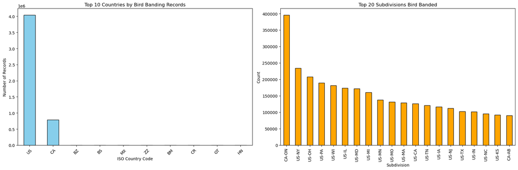

```python
# Geographical distribution of banding events

# Get top 10 countries and top 20 subdivisions
top_countries = df['ISO_COUNTRY'].value_counts().head(10)
top_subdivisions = df['ISO_SUBDIVISION'].value_counts().head(20)

# Create subplots
fig, axes = plt.subplots(1, 2, figsize=(18, 6))

# First subplot: Top 10 countries
top_countries.plot(kind='bar', color='skyblue', edgecolor='black', ax=axes[0])
axes[0].set_title("Top 10 Countries by Bird Banding Records")
axes[0].set_xlabel("ISO Country Code")
axes[0].set_ylabel("Number of Records")
axes[0].tick_params(axis='x', rotation=45)

# Second subplot: Top 20 subdivisions
top_subdivisions.plot(kind='bar', color='orange', edgecolor='black', ax=axes[1])
axes[1].set_title("Top 20 Subdivisions Bird Banded")
axes[1].set_xlabel("Subdivision")
axes[1].set_ylabel("Count")
axes[1].tick_params(axis='x', rotation=90)

plt.tight_layout()
plt.show()
```

### Individual species

```python
import matplotlib.pyplot as plt

# List of your 7 target species
species_list = df['SPECIES_NAME'].unique().tolist()


# Loop through each species
for species in species_list:
    species_df = df[df['SPECIES_NAME'] == species]
    species_year_counts = species_df['EVENT_YEAR'].value_counts().sort_index()

    if not species_year_counts.empty:
        # Print most and fewest events
        print(f"\n{species}")
        print(f"Year with most {species} band events: {species_year_counts.idxmax()}. Count: {species_year_counts.max()}")
        print(f"Year with fewest {species} band events: {species_year_counts.idxmin()}. Count: {species_year_counts.min()}")

        # Create and save plot
        plt.figure(figsize=(12, 6))
        species_year_counts.plot(kind="bar", color="darkgreen")
        plt.title(f"{species} Banding Events by Year", fontsize=16)
        plt.xlabel("Year", fontsize=14)
        plt.ylabel("Event Count", fontsize=14)
        plt.xticks(rotation=90, fontsize=12)
        plt.yticks(fontsize=10)
        plt.grid(axis="y", linestyle="--")
        plt.tight_layout()

        filename = f"species_year/{species.lower().replace(' ', '_')}_banding_by_year.png"
        #plt.savefig(filename)
        plt.close()
    else:
        print(f"\n{species}: No data available.")
```

```
Wood Duck
Year with most Wood Duck band events: 2015.0. Count: 44520
Year with fewest Wood Duck band events: 1973.0. Count: 17513

Mourning Dove
Year with most Mourning Dove band events: 1971.0. Count: 163649
Year with fewest Mourning Dove band events: 1978.0. Count: 9835

Tree Swallow
Year with most Tree Swallow band events: 2012.0. Count: 30698
Year with fewest Tree Swallow band events: 1970.0. Count: 5455

Gray Catbird
Year with most Gray Catbird band events: 2015.0. Count: 24672
Year with fewest Gray Catbird band events: 1973.0. Count: 12616

American Goldfinch
Year with most American Goldfinch band events: 1978.0. Count: 34257
Year with fewest American Goldfinch band events: 2019.0. Count: 13213

White-throated Sparrow
Year with most White-throated Sparrow band events: 1975.0. Count: 31268
Year with fewest White-throated Sparrow band events: 2019.0. Count: 17836

Canada Goose
Year with most Canada Goose band events: 2018.0. Count: 88638
Year with fewest Canada Goose band events: 1972.0. Count: 35335
```

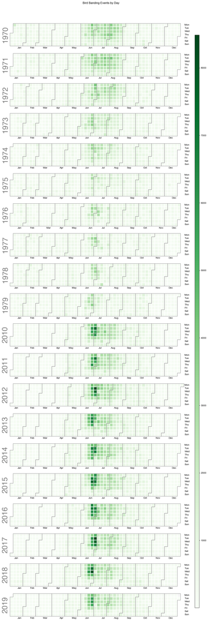

```python
# Calendar heatmap of bird banding events

plt.rcParams['font.family'] = 'Arial'  # or 'Arial', 'sans-serif'

# Combine date columns into a datetime column
df['EVENT_DATE'] = pd.to_datetime(df['EVENT_DATE'], errors='coerce')

# Drop missing or malformed dates
#df = df.dropna(subset=['EVENT_DATE'])

# Count events per day
daily_counts = df['EVENT_DATE'].value_counts().sort_index()

# Create calendar heatmap
cp.calplot(daily_counts, how='sum', cmap="Greens",colorbar=True, suptitle='Bird Banding Events by Day')

# Save the plot as an image file
#plt.savefig("./plots/event_cal_plot.png", dpi=300, bbox_inches="tight")
plt.show()
```

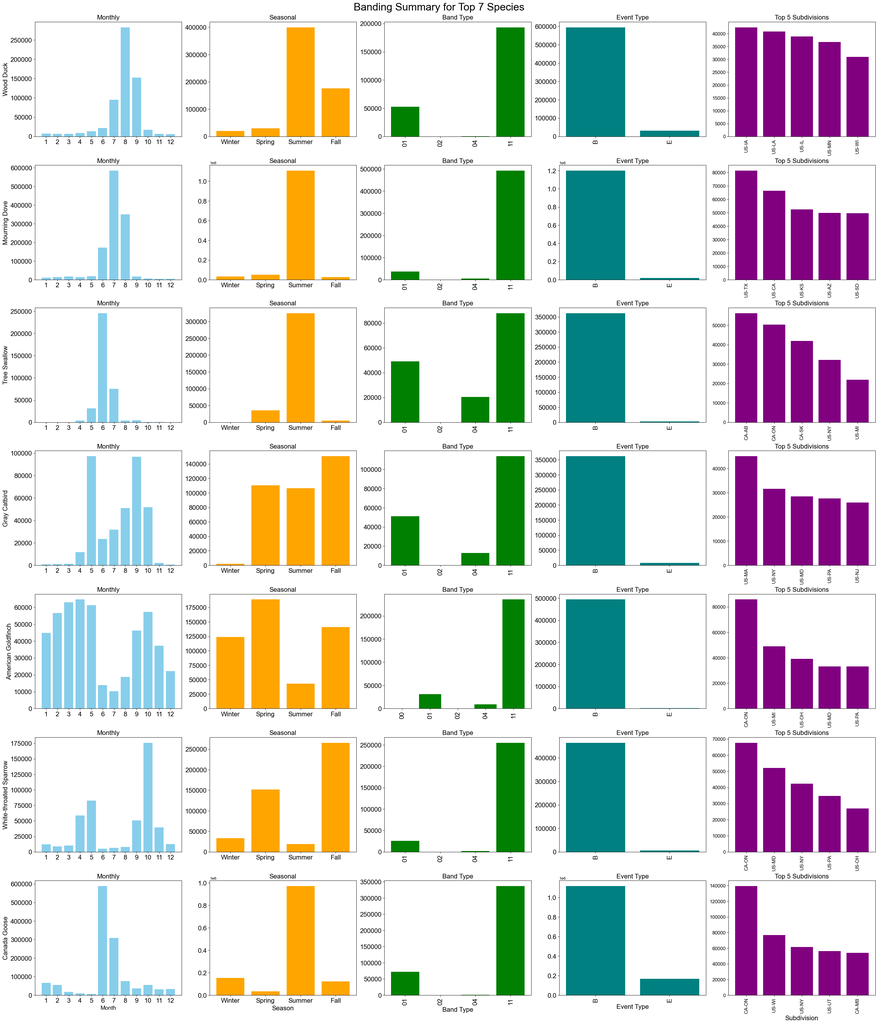

```python
# Map months to seasons
season_map = {
    12: 'Winter', 1: 'Winter', 2: 'Winter',
    3: 'Spring', 4: 'Spring', 5: 'Spring',
    6: 'Summer', 7: 'Summer', 8: 'Summer',
    9: 'Fall', 10: 'Fall', 11: 'Fall'
}
df['SEASON'] = df['EVENT_MONTH'].map(season_map)

# Get top 7 species
species_list = df['SPECIES_NAME'].dropna().unique()[:7]

# Create 7 rows × 5 columns plot grid
fig, axes = plt.subplots(nrows=7, ncols=5, figsize=(30, 35), constrained_layout=True)
fig.suptitle("Banding Summary for Top 7 Species", fontsize=26)

for i, species in enumerate(species_list):
    species_df = df[df['SPECIES_NAME'] == species]

    # Monthly & seasonal distribution
    monthly = species_df['EVENT_MONTH'].value_counts().sort_index()
    seasonal = species_df['SEASON'].value_counts().reindex(['Winter', 'Spring', 'Summer', 'Fall'])

    # Band & event types
    band_type = species_df['BAND_TYPE'].value_counts()
    event_type = species_df['EVENT_TYPE'].value_counts()
    band_type = band_type.reindex(['00', '01', '02', '04', '11'])
    event_type = event_type.reindex(['B', 'E'])

    # Top 20 subdivisions
    subdivisions = species_df['ISO_SUBDIVISION'].value_counts().head(5)

    # Plot 1: Monthly
    axes[i, 0].bar(monthly.index, monthly.values, color='skyblue')
    axes[i, 0].set_xticks(range(1, 13))
    axes[i, 0].set_title("Monthly", fontsize=16)
    axes[i, 0].tick_params(axis='both', labelsize=16)
    if i == 6:
        axes[i, 0].set_xlabel("Month", fontsize=14)
    axes[i, 0].set_ylabel(species, fontsize=16)

    # Plot 2: Seasonal
    axes[i, 1].bar(seasonal.index, seasonal.values, color='orange')
    axes[i, 1].set_title("Seasonal", fontsize=16)
    axes[i, 1].tick_params(axis='both', labelsize=16)
    if i == 6:
        axes[i, 1].set_xlabel("Season", fontsize=16)

    # Plot 3: Band type
    axes[i, 2].bar(band_type.index, band_type.values, color='green')
    axes[i, 2].set_title("Band Type", fontsize=16)
    axes[i, 2].tick_params(axis='both', labelsize=16)
    axes[i, 2].tick_params(axis='x', rotation=90)
    if i == 6:
        axes[i, 2].set_xlabel("Band Type", fontsize=16)

    # Plot 4: Event type
    axes[i, 3].bar(event_type.index, event_type.values, color='teal')
    axes[i, 3].set_title("Event Type", fontsize=16)
    axes[i, 3].tick_params(axis='both', labelsize=16)
    axes[i, 3].tick_params(axis='x', rotation=90)
    if i == 6:
        axes[i, 3].set_xlabel("Event Type", fontsize=16)

    # Plot 5: Subdivisions
    axes[i, 4].bar(subdivisions.index, subdivisions.values, color='purple')
    axes[i, 4].set_title("Top 5 Subdivisions", fontsize=16)
    axes[i, 4].tick_params(axis='both', labelsize=12)
    axes[i, 4].tick_params(axis='x', rotation=90)
    if i == 6:
        axes[i, 4].set_xlabel("Subdivision", fontsize=16)

plt.show()
```